# Landers Examples

Daniel Carr

October 12, 2017

## 0. Setup

```r
library(ggplot2)
library(useful)
library(coefplot)
source('hw.R')

 acs <- read.table("http://jaredlander.com/data/acs_ny.csv",
  sep = ',', header = TRUE, stringsAsFactors = FALSE)
```

## 1. A look at the 2010 American Community Survery (ACS) for New York State

Below, Landers creates an a binary income variable called Income. In a numeric setting values of TRUE are interpreted as 1 and values of FALSE are intrpreted as 0.  
The variable can be thought of as Bernoulli random variable or a binomial random variable with a sample size of 1.

```r
acs$Income <- with(acs,FamilyIncome >= 150000)
```

Below look at the density for Family Income and threshhold used to defined the binary variable Income.

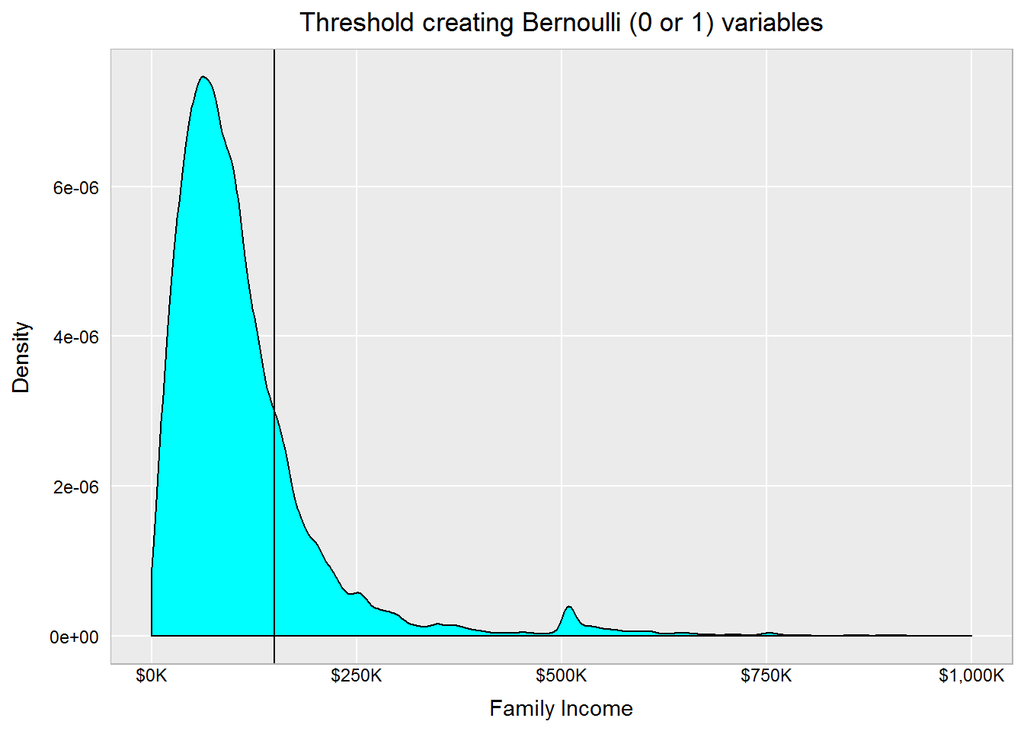

```r
ggplot(acs, aes(x = FamilyIncome)) +
  geom_density(fill = 'cyan', color = 'black') +
  geom_vline(xintercept = 150000) +
  scale_x_continuous(label = multiple.dollar, limits = c(0,1000000)) +
  labs(x = 'Family Income',y =  'Density',
    title = 'Threshold creating Bernoulli (0 or 1) variables') + hw
```

Look at the first six cases.

```r
head( acs)
```

```
##   Acres FamilyIncome  FamilyType NumBedrooms NumChildren NumPeople
## 1  1-10          150     Married           4           1         3
## 2  1-10          180 Female Head           3           2         4
## 3  1-10          280 Female Head           4           0         2
## 4  1-10          330 Female Head           2           1         2
## 5  1-10          330   Male Head           3           1         2
## 6  1-10          480   Male Head           0           3         4
##   NumRooms        NumUnits NumVehicles NumWorkers  OwnRent   YearBuilt
## 1        9 Single detached           1          0 Mortgage   1950-1959
## 2        6 Single detached           2          0   Rented Before 1939
## 3        8 Single detached           3          1 Mortgage   2000-2004
## 4        4 Single detached           1          0   Rented   1950-1959
## 5        5 Single attached           1          0 Mortgage Before 1939
## 6        1 Single detached           0          0   Rented Before 1939
##   HouseCosts ElectricBill FoodStamp HeatingFuel Insurance       Language
## 1       1800           90        No         Gas      2500        English
## 2        850           90        No         Oil         0        English
## 3       2600          260        No         Oil      6600 Other European
## 4       1800          140        No         Oil         0        English
## 5        860          150        No         Gas       660        Spanish
## 6        700          140        No         Gas         0        English
##   Income
## 1  FALSE
## 2  FALSE
## 3  FALSE
## 4  FALSE
## 5  FALSE
## 6  FALSE
```

## 2. Fitting binomal data

Below we use generalized linear model function, glm(), to model probability that Income = 1 as inverse logit function (equation 20.2) oa a linear combination of fixed explanatory variables. That is, we choose the binomial distribution as the probability family and ‘logit’ as the function that links the linear combination of explanatory variables to the probability of income being 1.

```r
income1 <- glm( Income ~ HouseCosts + NumWorkers + OwnRent+
  NumBedrooms + FamilyType, data = acs,
  family = binomial(link = 'logit'))
summary( income1 )
```

```
##
## Call:
## glm(formula = Income ~ HouseCosts + NumWorkers + OwnRent + NumBedrooms +
##     FamilyType, family = binomial(link = "logit"), data = acs)
##
## Deviance Residuals:
##     Min       1Q   Median       3Q      Max
## -2.8452  -0.6246  -0.4231  -0.1743   2.9503
##
## Coefficients:
##                       Estimate Std. Error z value Pr(>|z|)
## (Intercept)         -5.738e+00  1.185e-01 -48.421   <2e-16 ***
## HouseCosts           7.398e-04  1.724e-05  42.908   <2e-16 ***
## NumWorkers           5.611e-01  2.588e-02  21.684   <2e-16 ***
## OwnRentOutright      1.772e+00  2.075e-01   8.541   <2e-16 ***
## OwnRentRented       -8.886e-01  1.002e-01  -8.872   <2e-16 ***
## NumBedrooms          2.339e-01  1.683e-02  13.895   <2e-16 ***
## FamilyTypeMale Head  3.336e-01  1.472e-01   2.266   0.0235 *
## FamilyTypeMarried    1.405e+00  8.704e-02  16.143   <2e-16 ***
## ---
## Signif. codes:  0 '***' 0.001 '**' 0.01 '*' 0.05 '.' 0.1 ' ' 1
##
## (Dispersion parameter for binomial family taken to be 1)
##
##     Null deviance: 22808  on 22744  degrees of freedom
## Residual deviance: 18073  on 22737  degrees of freedom
## AIC: 18089
##
## Number of Fisher Scoring iterations: 6
```

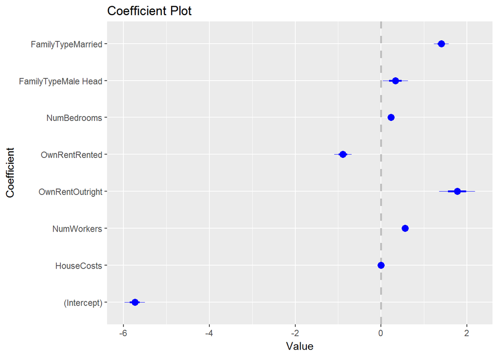

```r
coefplot(income1)
```

Above, the housing cost filled circle hides the confidence interal that is very small. The table indicates this the regression cooefficient is also statistically significant.

Interpreting the coefficents for a logistic regression in their original units involves using the inverse logit function.

```r
invlogit <- function(x) {
  1/(1+exp(-x))
}

invlogit(income1$coefficients)
```

```
##         (Intercept)          HouseCosts          NumWorkers
##         0.003211572         0.500184950         0.636702036
##     OwnRentOutright       OwnRentRented         NumBedrooms
##         0.854753527         0.291408659         0.558200010
## FamilyTypeMale Head   FamilyTypeMarried
##         0.582624773         0.802983719
```

## 3. Fitting Count Data with Poisson and Negative Binomal models

Next we modelthe number of children in the acs data. These are counts.

The Poisson distribution is a popular distribution for fitting count data. The Poisson distribution has one parameter, denoted lambda in Lander’s equation 17.6). (The distribution in wrong in Table 17.2) The parameter is both the mean and the variance of the distribution.

```r
mean(acs$NumChildren)
```

```
## [1] 0.9011651
```

```r
var(acs$NumChildren)
```

```
## [1] 1.344522
```

Perhaps fitting the model results look better.

```r
children1 <- glm(NumChildren ~ FamilyIncome + FamilyType + OwnRent,
  family = poisson(link = 'log'),data = acs)
summary(children1)
```

```
##
## Call:
## glm(formula = NumChildren ~ FamilyIncome + FamilyType + OwnRent,
##     family = poisson(link = "log"), data = acs)
##
## Deviance Residuals:
##     Min       1Q   Median       3Q      Max
## -1.9950  -1.3235  -1.2045   0.9464   6.3781
##
## Coefficients:
##                       Estimate Std. Error z value Pr(>|z|)
## (Intercept)         -3.257e-01  2.103e-02 -15.491  < 2e-16 ***
## FamilyIncome         5.420e-07  6.572e-08   8.247  < 2e-16 ***
## FamilyTypeMale Head -6.298e-02  3.847e-02  -1.637    0.102
## FamilyTypeMarried    1.440e-01  2.147e-02   6.707 1.98e-11 ***
## OwnRentOutright     -1.974e+00  2.292e-01  -8.611  < 2e-16 ***
## OwnRentRented        4.086e-01  2.067e-02  19.773  < 2e-16 ***
## ---
## Signif. codes:  0 '***' 0.001 '**' 0.01 '*' 0.05 '.' 0.1 ' ' 1
##
## (Dispersion parameter for poisson family taken to be 1)
##
##     Null deviance: 35240  on 22744  degrees of freedom
## Residual deviance: 34643  on 22739  degrees of freedom
## AIC: 61370
##
## Number of Fisher Scoring iterations: 5
```

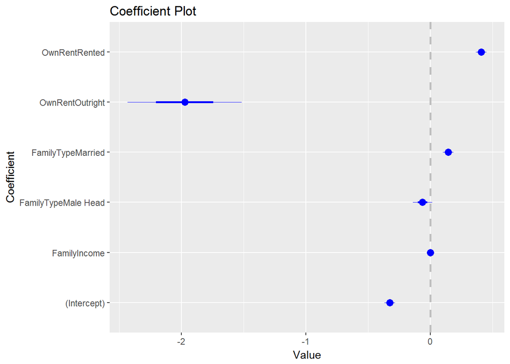

```r
coefplot(children1)
```

Overdispersion, OD, is defined by the sum of studentized residuals squared divided by n-p, the degrees of freedom.

```r
check1 <- acs$NumChildren - children1$fitted.values
check2 <- children1$residuals

z <- (acs$NumChildren - children1$fitted.values) /
  sqrt(children1$fitted.values)

sum(z^2)/children1$df.residual
```

```
## [1] 1.469747
```

```r
pchisq(sum(z^2),children1$df.residual)
```

```
## [1] 1
```

I have not verified the above calculation methods. The overdispersion is statistically significant. Using an apparent rule of thumb the 1.469 is not bigger than 2 the Poisson model is not so bad.

While not obvious from the function call modeling below is really based onnegative binomial model, that address the overdisperion issue.

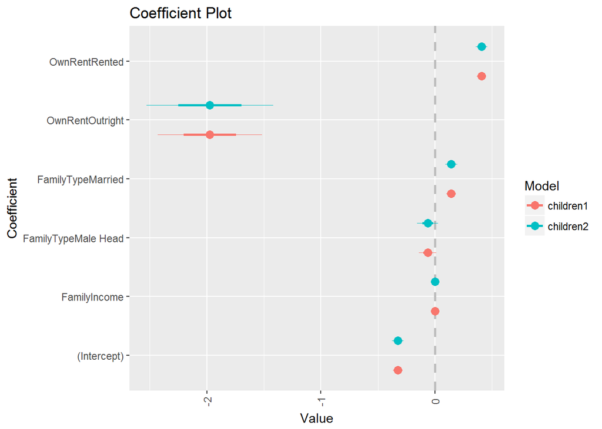

```r
children2 <- glm(NumChildren ~ FamilyIncome + FamilyType + OwnRent,
  data = acs, family = quasipoisson(link='log'))
multiplot(children1, children2)
```

“Because the overdispersion is not too big the coefficient estimates in the second model have just a bit more uncertainty.”